# Lesson 5

### Multivariate Data

Notes:

### Moira Perceived Audience Size Colored by Age

Notes: the idea is that perceived audience size accuracy might change with age (older people being more accurate about the size). Scatterplot with coloured points (cololur => age) didn’t show a clear answer.

### Third Qualitative Variable

Notes:

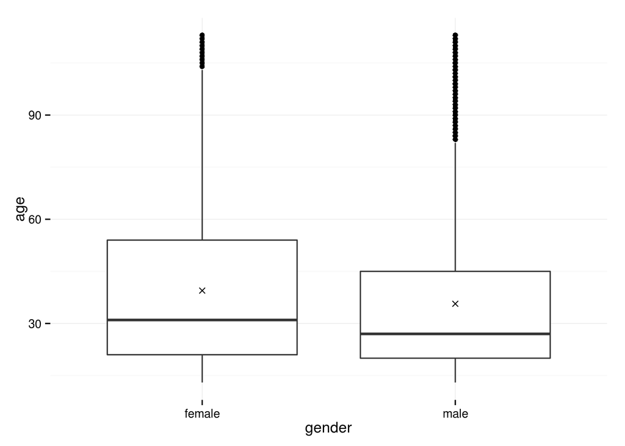

```r
library(ggplot2)
library(ggthemes)
theme_set(theme_minimal())
pf <- read.csv('pseudo_facebook.tsv', sep = '\t')
# Female  FB users are generally older than males.
ggplot(aes(x = gender, y = age),
       data = subset(pf, !is.na(gender))) +
  geom_boxplot() +
  stat_summary(fun.y = mean, geom = 'point', shape = 4)
```

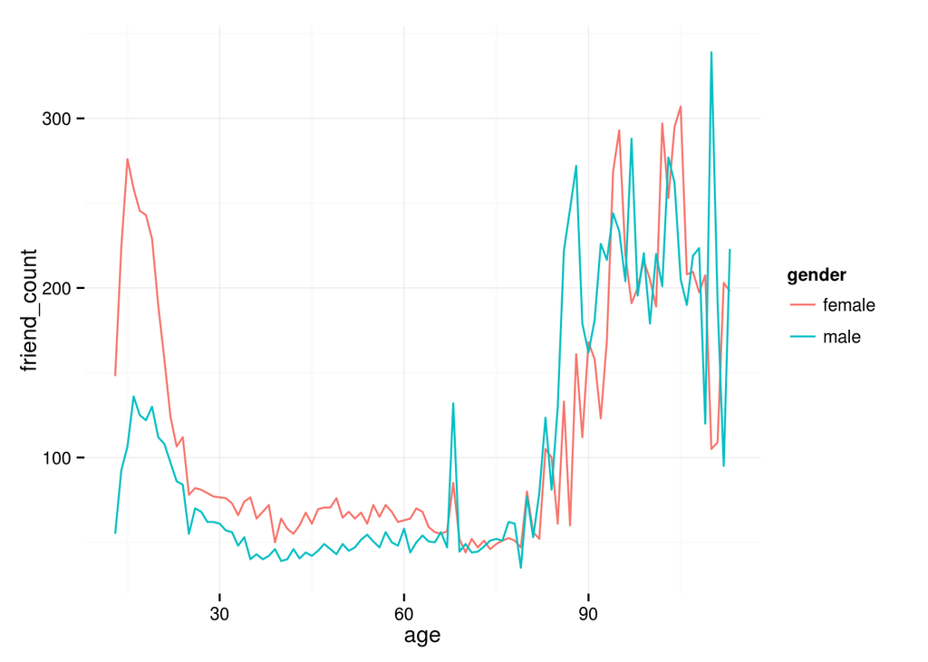

```r
# Median # of friends, per age
ggplot(aes(x = age, y = friend_count),
       data = subset(pf, !is.na(gender))) +
  geom_line(aes(color = gender), stat = 'summary', fun.y = median)
```

#### Excercise

Write code to create a new data frame, called ‘pf.fc_by_age_gender’, that contains information on each age AND gender group.

The data frame should contain the following variables:

- mean_friend_count,
- median_friend_count,
- n (the number of users in each age and gender grouping)

```r
library(dplyr)
pf.fc_by_age_gender = pf %>%
  filter(!is.na(gender)) %>%
  group_by(age, gender) %>%
  summarise(mean_friend_count = mean(friend_count),
            median_friend_count = median(friend_count),
            n = n()) %>%
  ungroup() %>%
  arrange(age)
pf.fc_by_age_gender
```

```
## Source: local data frame [202 x 5]
##
##      age gender mean_friend_count median_friend_count     n
##    (int) (fctr)             (dbl)               (dbl) (int)
## 1     13 female          259.1606               148.0   193
## 2     13   male          102.1340                55.0   291
## 3     14 female          362.4286               224.0   847
## 4     14   male          164.1456                92.5  1078
## 5     15 female          538.6813               276.0  1139
## 6     15   male          200.6658               106.5  1478
## 7     16 female          519.5145               258.5  1238
## 8     16   male          239.6748               136.0  1848
## 9     17 female          538.9943               245.5  1236
## 10    17   male          236.4924               125.0  2045
## ..   ...    ...               ...                 ...   ...
```

### Plotting Conditional Summaries

Notes: with the conditional summaries inside dataframe, we no longer need to use ‘stat’ and ‘fun.y’ parameters to geom_line.

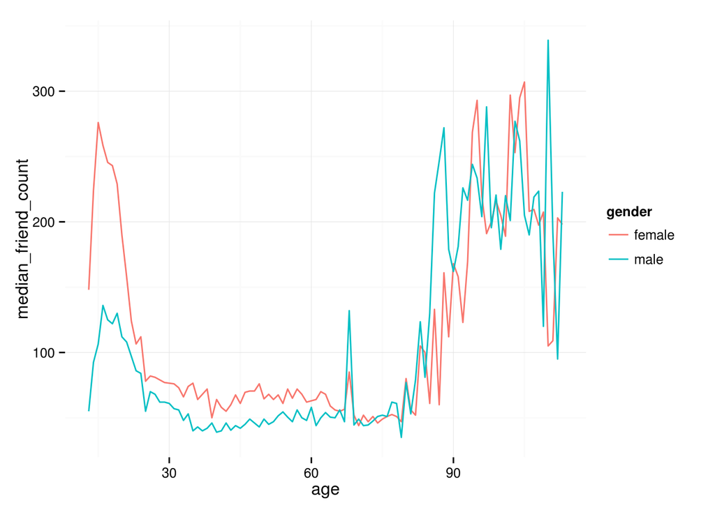

```r
ggplot(aes(x = age, y = median_friend_count), data =pf.fc_by_age_gender) +
  geom_line(aes(color = gender))
```

### Thinking in Ratios

Notes: charts shows that friend count difference is larger for younger users. We’d like to see a ratio: how many more friends do girls have. Does the ratio hold in time?

### Wide and Long Format

Notes:

Long format: (age, gender) -> (observations)

Wide format: (age) -> (observation for male, observation for female)

### Reshaping Data

Notes:

```r
library(tidyr)
library(reshape2)

# rehape with tidyr (note 'spread' and 'mutate')
pf.fc_by_age_gender.wide <-
  subset(pf.fc_by_age_gender[c('age', 'gender', 'median_friend_count')], !is.na(gender)) %>%
    spread(gender, median_friend_count) %>%
    mutate(ratio = male / female)
head(pf.fc_by_age_gender.wide)
```

```
## Source: local data frame [6 x 4]
##
##     age female  male     ratio
##   (int)  (dbl) (dbl)     (dbl)
## 1    13  148.0  55.0 0.3716216
## 2    14  224.0  92.5 0.4129464
## 3    15  276.0 106.5 0.3858696
## 4    16  258.5 136.0 0.5261122
## 5    17  245.5 125.0 0.5091650
## 6    18  243.0 122.0 0.5020576
```

```r
pf.fc_by_age_gender.wide <- dcast(pf.fc_by_age_gender,
                                  age ~ gender,
                                  value.var = 'median_friend_count')
head(pf.fc_by_age_gender.wide)
```

```
##   age female  male
## 1  13  148.0  55.0
## 2  14  224.0  92.5
## 3  15  276.0 106.5
## 4  16  258.5 136.0
## 5  17  245.5 125.0
## 6  18  243.0 122.0
```

### Ratio Plot

Notes:

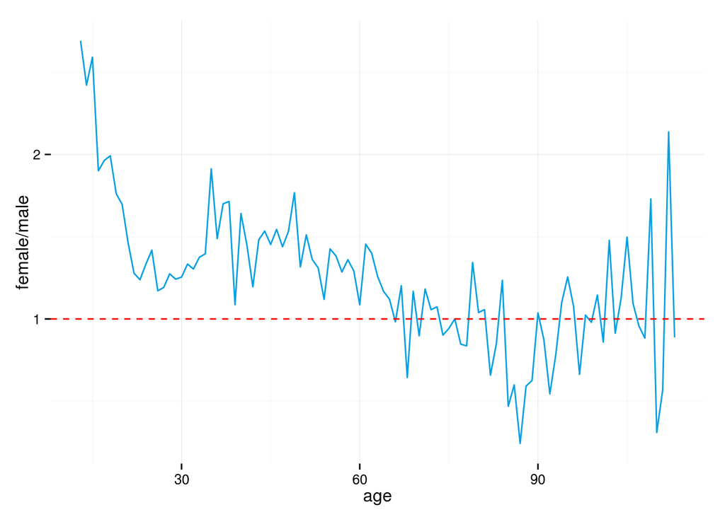

```r
# Plot the ratio of the female to male median friend counts using the data frame pf.fc_by_age_gender.wide.

# Think about what geom you should use.
# Add a horizontal line to the plot with a y intercept of 1, which will be the base line.
# Look up the documentation for geom_hline to do that. Use the parameter linetype in geom_hline to make the line dashed.

# The linetype parameter can take the values 0-6:
# 0 = blank, 1 = solid, 2 = dashed, 3 = dotted, 4 = dotdash, 5 = longdash, 6 = twodash
ggplot(aes(x = age, y = female / male), data = pf.fc_by_age_gender.wide) +
  geom_line(color = '#02a0e2') +
  geom_hline(yintercept = 1, color = 'red', linetype = 2)
```

### Third Quantitative Variable

Notes: from the graph above, female have more friends than males (> 2 times more for young users). Hypothesis: there is lots of male who are new-joiners and haven’t build their friends list yet. We want to analyze the ratio based on account age (tenure).

```r
pf$year_joined <- 2014 - ceiling(pf$tenure / 365)
# optionally:  pf$year_joined <- floor(2014 - pf$tenure / 365)
```

### Cut a Variable

Notes: there are not many users for 2005 and 2006, so we want to group the early years users together.

```r
summary(pf$year_joined)
```

```
##    Min. 1st Qu.  Median    Mean 3rd Qu.    Max.    NA's
##    2005    2012    2012    2012    2013    2014       2
```

```r
table(pf$year_joined)
```

```
##
##  2005  2006  2007  2008  2009  2010  2011  2012  2013  2014
##     9    15   581  1507  4557  5448  9860 33366 43588    70
```

```r
pf$year_joined.bucket <- cut(pf$year_joined, breaks = c(2004, 2009, 2011, 2012, 2014))
summary(pf$year_joined.bucket)
```

```
## (2004,2009] (2009,2011] (2011,2012] (2012,2014]        NA's
##        6669       15308       33366       43658           2
```

### Plotting it All Together

Notes: plot belows confirms the thesies: user who are longer of facebook (bigger tenure) have more friends.

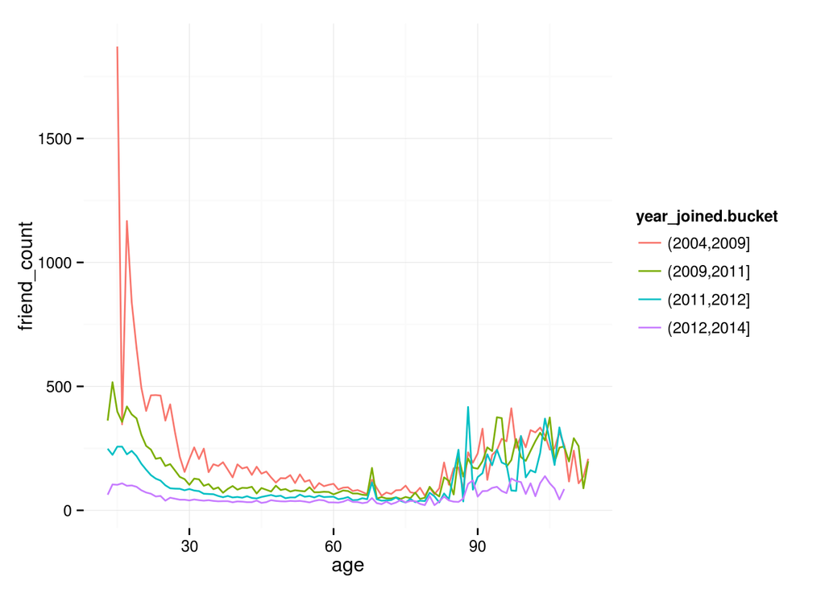

```r
# Create a line graph of friend_count vs. age so that each year_joined.bucket is a line
# tracking the median user friend_count across age. This means you should have four different
# lines on your plot.

# You should subset the data to exclude the users whose year_joined.bucket is NA.
ggplot(aes(x = age, y = friend_count), data = subset(pf, !is.na(year_joined.bucket))) +
  geom_line(aes(color = year_joined.bucket), stat = 'summary', fun.y = median)
```

### Plot the Grand Mean

Notes: grand mean is low (below the [2011-2012] cohort), which means that large number of users are in the last cohort and bring the grand mean down.

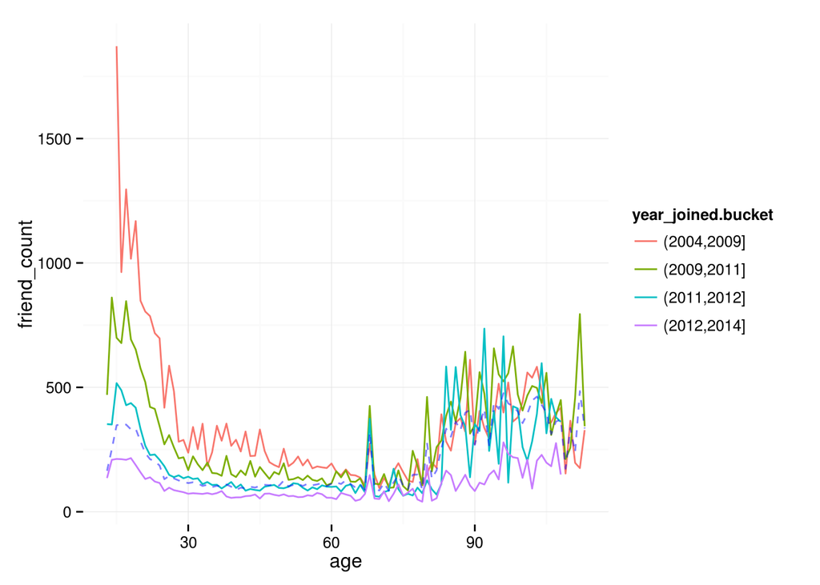

```r
# Write code to do the following:

# (1) Add another geom_line to code below to plot the grand mean of the friend count vs age.
# (2) Exclude any users whose year_joined.bucket is NA.
# (3) Use a different line type for the grand mean.

# As a reminder, the parameter linetype can take the values 0-6:
# 0 = blank, 1 = solid, 2 = dashed, # 3 = dotted, 4 = dotdash, 5 = longdash, # 6 = twodash
ggplot(aes(x = age, y = friend_count), data = subset(pf, !is.na(year_joined.bucket))) +
  geom_line(aes(color = year_joined.bucket), stat = 'summary', fun.y = mean) +
  geom_line(stat = 'summary', fun.y = mean, color = 'blue', alpha = 0.5, linetype = 2)
```

### Friending Rate

Notes:

```r
friend_rate <- subset(pf, tenure >= 1)
friend_rate <- friend_rate$friend_count / friend_rate$tenure
summary(friend_rate)
```

```
##     Min.  1st Qu.   Median     Mean  3rd Qu.     Max.
##   0.0000   0.0775   0.2205   0.6096   0.5658 417.0000
```

```r
# alt
# with(subset(pf, tenure >= 1), summary(friend_count / tenure))
```

### Friendships Initiated

Notes:

What is the median friend rate?

0.2205

What is the maximum friend rate?

417.0000

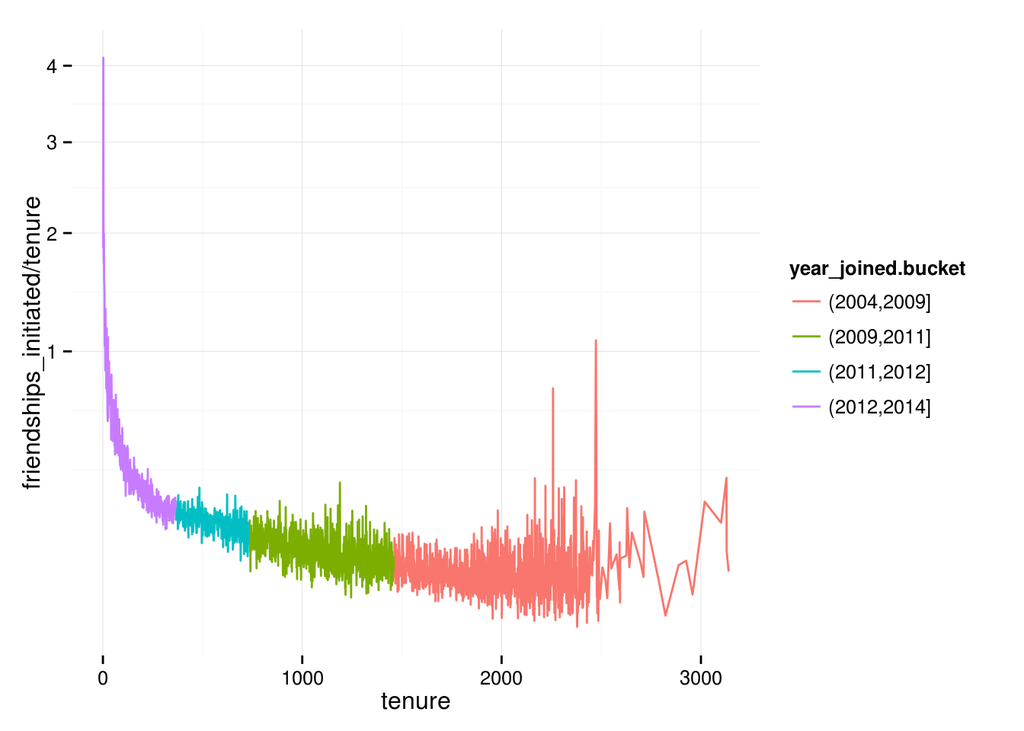

```r
# Create a line graph of mean of friendships_initiated per day (of tenure)
# vs. tenure colored by year_joined.bucket.

# You need to make use of the variables tenure, friendships_initiated, and year_joined.bucket.
ggplot(aes(x = tenure, y = friendships_initiated / tenure), data = subset(pf, tenure >= 1)) +
  geom_line(aes(color = year_joined.bucket), stat = 'summary', fun.y = mean) +
  scale_y_sqrt()
```

### Bias-Variance Tradeoff Revisited

Notes: understanding bias vs variance: http://scott.fortmann-roe.com/docs/BiasVariance.html

Books: The Elements of Statistical Learning: http://statweb.stanford.edu/~tibs/ElemStatLearn/

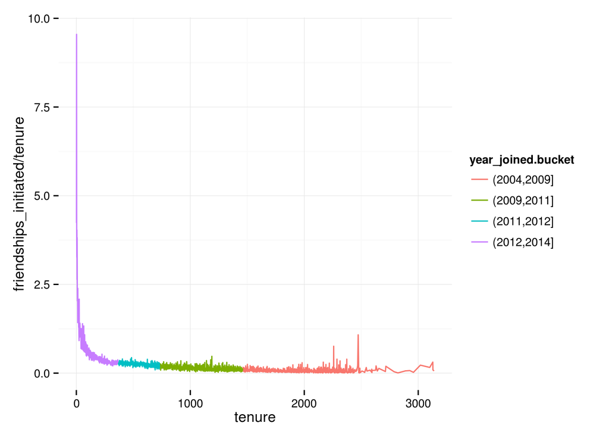

```r
ggplot(aes(x = tenure, y = friendships_initiated / tenure),
       data = subset(pf, tenure >= 1)) +
  geom_line(aes(color = year_joined.bucket),
            stat = 'summary',
            fun.y = mean)
```

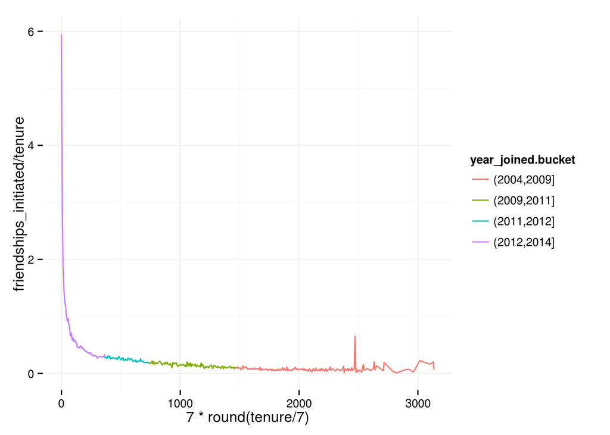

```r
ggplot(aes(x = 7 * round(tenure / 7), y = friendships_initiated / tenure),
       data = subset(pf, tenure > 0)) +
  geom_line(aes(color = year_joined.bucket),
            stat = "summary",
            fun.y = mean)
```

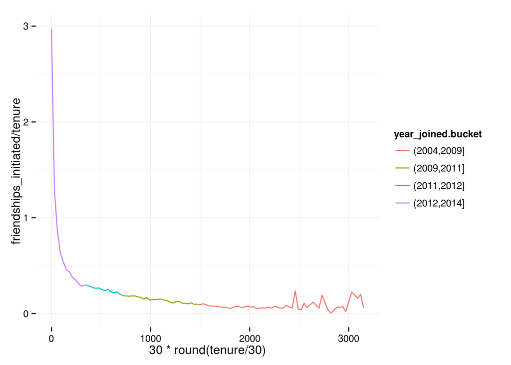

```r
ggplot(aes(x = 30 * round(tenure / 30), y = friendships_initiated / tenure),
       data = subset(pf, tenure > 0)) +
  geom_line(aes(color = year_joined.bucket),
            stat = "summary",
            fun.y = mean)
```

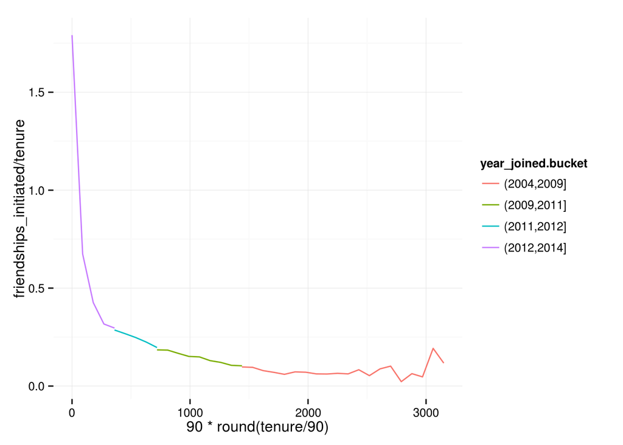

```r
ggplot(aes(x = 90 * round(tenure / 90), y = friendships_initiated / tenure),
       data = subset(pf, tenure > 0)) +
  geom_line(aes(color = year_joined.bucket),
            stat = "summary",
            fun.y = mean)
```

```
## geom_smooth: method="auto" and size of largest group is >=1000, so using gam with formula: y ~ s(x, bs = "cs"). Use 'method = x' to change the smoothing method.
```

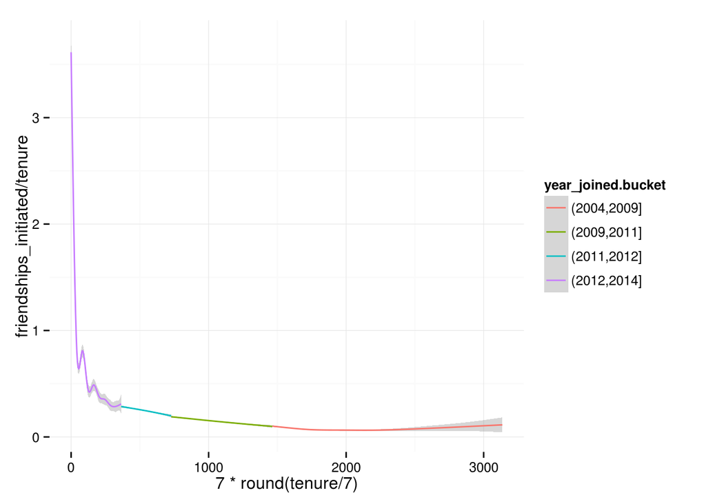

```r
# finally, we can use geom_smooth to add smoother to the plot
ggplot(aes(x = 7 * round(tenure / 7), y = friendships_initiated / tenure), data = subset(pf, tenure > 0)) +
  # geom_line(aes(color = year_joined.bucket), stat = "summary", fun.y = mean) +
  geom_smooth(aes(color = year_joined.bucket))
```

### Sean’s NFL Fan Sentiment Study

Links:

- The Emotional Highs and Lows of the NFL Season : https://www.facebook.com/notes/facebook-data-science/the-emotional-highs-and-lows-of-the-nfl-season/10152033221418859
- NFL on Wikipedia: https://en.wikipedia.org/wiki/National_Football_League
- analyst profile (seaj j. taylor): http://seanjtaylor.com/

Notes:

- measuring the emotions you experience on daily basisc (here: emotions of NFL games)
- metric: ratio of positive / negative words
- multiple models were wrong and did not tell the story that is known to NFL fans (emotional rollercoaster)
- **moving average** is very strong and flexible statistic that lets data to speak for itself
- 7-days-average + splines == mixed models showed the best story

### Introducing the Yogurt Data Set

Notes: yogurt dataset contains multiple rows per household; one per each transaction.

### Histograms Revisited

Notes:

```r
yo <- read.csv('yogurt.csv')

# Change the id from an int to a factor
yo$id <- factor(yo$id)
str(yo)
```

```
## 'data.frame':    2380 obs. of  9 variables:
##  $ obs        : int  1 2 3 4 5 6 7 8 9 10 ...
##  $ id         : Factor w/ 332 levels "2100081","2100370",..: 1 1 1 1 1 1 1 1 1 1 ...
##  $ time       : int  9678 9697 9825 9999 10015 10029 10036 10042 10083 10091 ...
##  $ strawberry : int  0 0 0 0 1 1 0 0 0 0 ...
##  $ blueberry  : int  0 0 0 0 0 0 0 0 0 0 ...
##  $ pina.colada: int  0 0 0 0 1 2 0 0 0 0 ...
##  $ plain      : int  0 0 0 0 0 0 0 0 0 0 ...
##  $ mixed.berry: int  1 1 1 1 1 1 1 1 1 1 ...
##  $ price      : num  59 59 65 65 49 ...
```

```
## stat_bin: binwidth defaulted to range/30. Use 'binwidth = x' to adjust this.
```

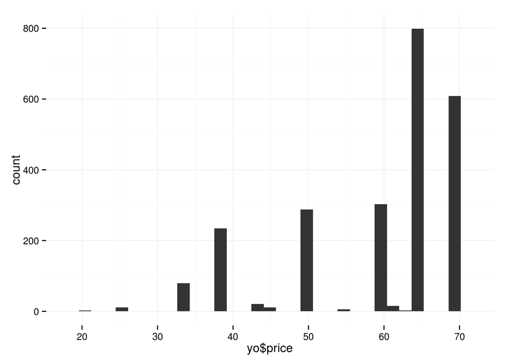

```r
ggplot(aes(x = yo$price), data = yo) +
  geom_histogram()
```

What do you notice?:

- there are few price values that show up in the graph. Multiple price values have no data at all (discrete dataset)
- there is more records with high prices (people tend to buy better tasting, more expensive yogurts or is it marketing effect?)
- some combinations of purchases are very rare; probably they mean rare combination of purchaases

### Number of Purchases

Notes:

- 3rd Quantile of price == Max
- not many distinct (unique) values (20)

```r
summary(yo$price)
```

```
##    Min. 1st Qu.  Median    Mean 3rd Qu.    Max.
##   20.00   50.00   65.04   59.25   68.96   68.96
```

```r
unique(yo$price)
```

```
##  [1] 58.96 65.04 48.96 68.96 39.04 24.96 50.00 45.04 33.04 44.00 33.36
## [12] 55.04 62.00 20.00 49.60 49.52 33.28 63.04 33.20 33.52
```

```r
# Create a new variable called all.purchases, which gives the total counts of yogurt for
# each observation or household.
yo$all.purchases <- rowSums(yo[,c('strawberry', 'blueberry', 'pina.colada', 'plain', 'mixed.berry')])
# alternative
# yo$all.purchases <- transform(yo, all.purchases = strawberry + blueberry + pina.colada + plain + mixed.berry)
```

### Prices over Time

Notes:

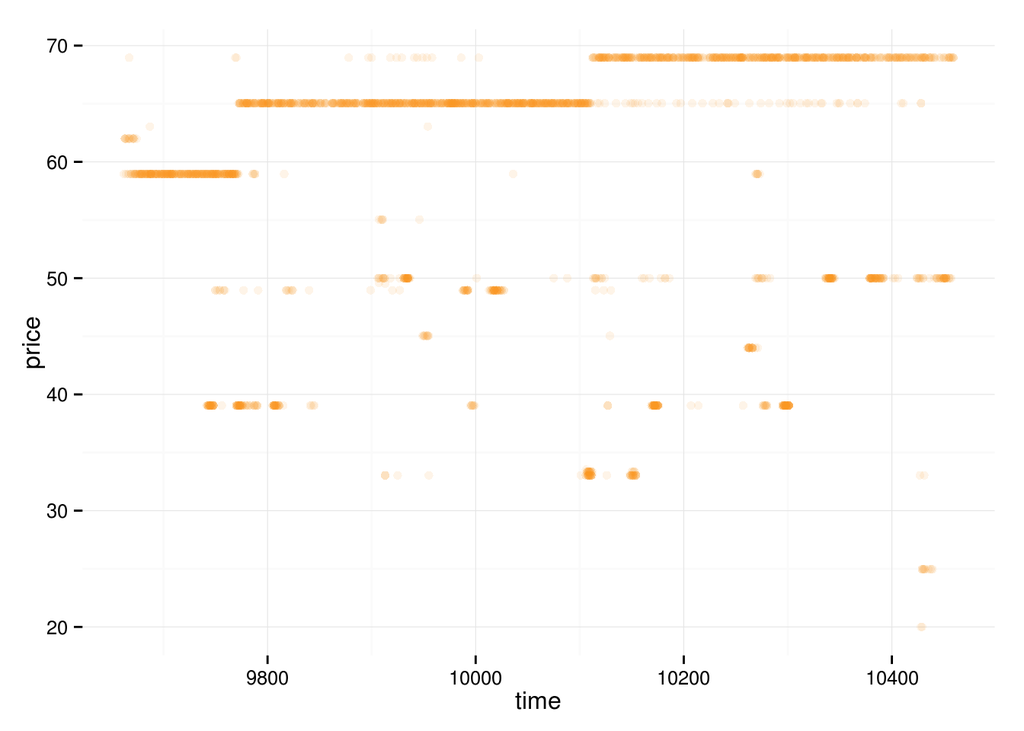

```r
# yo$all.purchases.factor = factor(yo$all.purchases)
ggplot(aes(x = time, y = price), data = yo) +
  geom_point(alpha = 0.1, color = I('#F79420'))
```

### Sampling Observations

Notes: when beginning with the dataset it’s often good to look at sample of the data.

In the yogurt dataset, it’s best to take a look at particular households to see variance within the household and between the households.

- how often they’re buying yogurt?
- at what price they’re buying

### Looking at Samples of Households

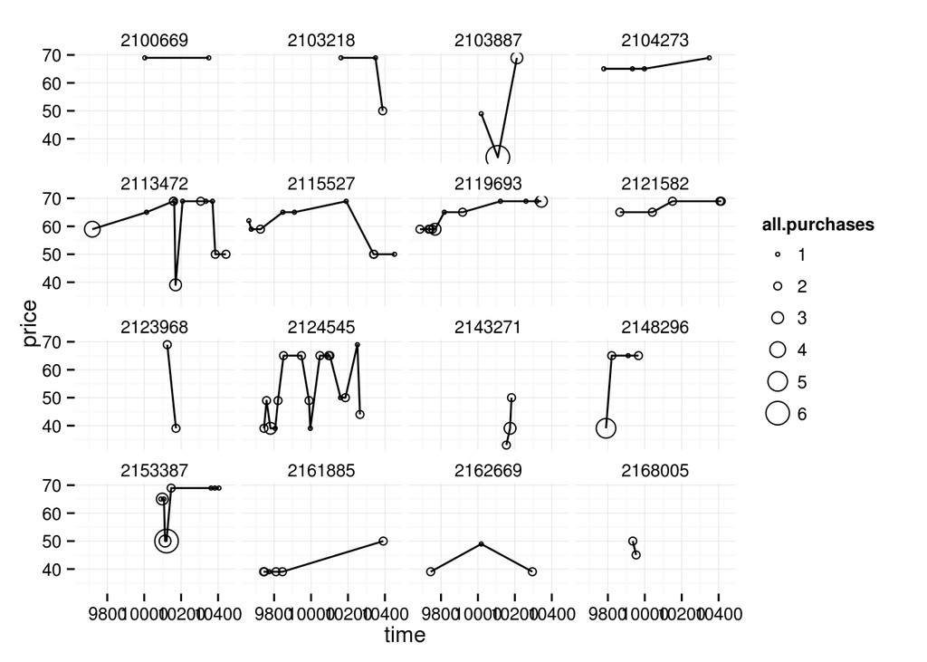

```r
# set the seed for reproducible results
set.seed(4000)
sample.ids <- sample(levels(yo$id), 16)

ggplot(aes(x = time, y = price), data = subset(yo, id %in% sample.ids)) +
  facet_wrap( ~ id) +
  geom_line() +
  geom_point(aes(size = all.purchases), pch = 1)
```

Notes:

- plots show differences in the qunatity and frequencies of purchases
- generally, most of the households increase the price in time

Seed 4000:

- there are households who seem not to care about coupons (steady, high prices)
- there are households which do care about the coupons (sudden drops in the price). Also, there is usually larger quantity of yogurt bought on lower price
- price rather increase in time; households do not ‘downgrade’ to yougurt with lower prices

### The Limits of Cross Sectional Data

Notes: if we have observations over time, we can facet them using primary id (household id)

This cannot be done with FB data, because it’s snapshot of friendship counts at one moment in time.

### Many Variables

Notes: much of the analysis so far was focused on some pre-chosen variable, pair of variables, etc.

But we might:

- want visualizations of summaries to point to auxiliary, story-telling variable (especially, when there is a lot of them).
- visualize large set of variables
- look for relationships between many variables.

We can speed up the analysis, by producing many plots & comparisons at once.

### Scatterplot Matrix

```r
library(GGally)
theme_set(theme_minimal(20))

# set the seed for reproducible results
set.seed(1836)
pf_subset <- pf[, c(2:15)]
names(pf_subset)
```

```
##  [1] "age"                   "dob_day"
##  [3] "dob_year"              "dob_month"
##  [5] "gender"                "tenure"
##  [7] "friend_count"          "friendships_initiated"
##  [9] "likes"                 "likes_received"
## [11] "mobile_likes"          "mobile_likes_received"
## [13] "www_likes"             "www_likes_received"
```

[output not shown]

[figure not shown]

```r
ggpairs(pf_subset[sample.int(nrow(pf_subset), 1000), ], axisLabels = 'internal')
```

Notes:

- we have scatterplots and histograms for gender (categorical)

### Even More Variables

Notes:

### Heat Maps

Notes:

melting data: http://www.r-bloggers.com/melt/

```r
nci <- read.table("nci.tsv")

# changing the colnames to produce a nicer plot
colnames(nci) <- c(1:64)
```

```r
nci.long.samp <- melt(as.matrix(nci[1:200,]))
names(nci.long.samp) <- c("gene", "case", "value")
head(nci.long.samp)
```

```
##   gene case  value
## 1    1    1  0.300
## 2    2    1  1.180
## 3    3    1  0.550
## 4    4    1  1.140
## 5    5    1 -0.265
## 6    6    1 -0.070
```

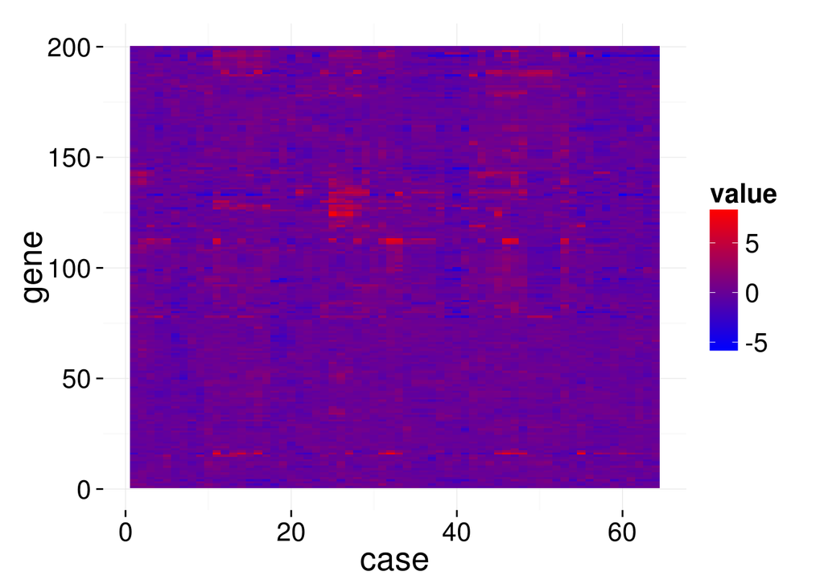

```r
ggplot(aes(y = gene, x = case, fill = value),
  data = nci.long.samp) +
  geom_tile() +
  scale_fill_gradientn(colours = colorRampPalette(c("blue", "red"))(100))
```

### Analyzing Three of More Variables

Reflection:

- extra variables (3rd, 4th) might provide insight into problem/observation that did not have clear explanation with smaller number of variables (here: # of friends per age, gender and account tenure)
- explore with different statistics and plots (NFL data: splines and moving means) to find the effect you’re looking for
- sample the data (rows and columns) to grab initial idea of what’s going on
- don’t be afraid to ‘start wide’ with many variables on scatterplots matrices, heatmaps and so. Let those point you at data to dig in deeper

Click **KnitHTML** to see all of your hard work and to have an html page of this lesson, your answers, and your notes!